Home > Archives > Ggplot2直方图

# Ggplot2直方图

Publish: March 3, 2015

# 直方图

zengfan

2015年3月2日

## 三个主要的数据图形

三个主要的数据图形分别是线图、bar（直方）图、和散点图。在ggplot2作图系统中，你需要一般完成以下几步：

1. 指定数据集
2. 在数据集中指定数据关系
3. 画图

下面我们简单介绍直方图。

## 直方图

首先我们来看代码。

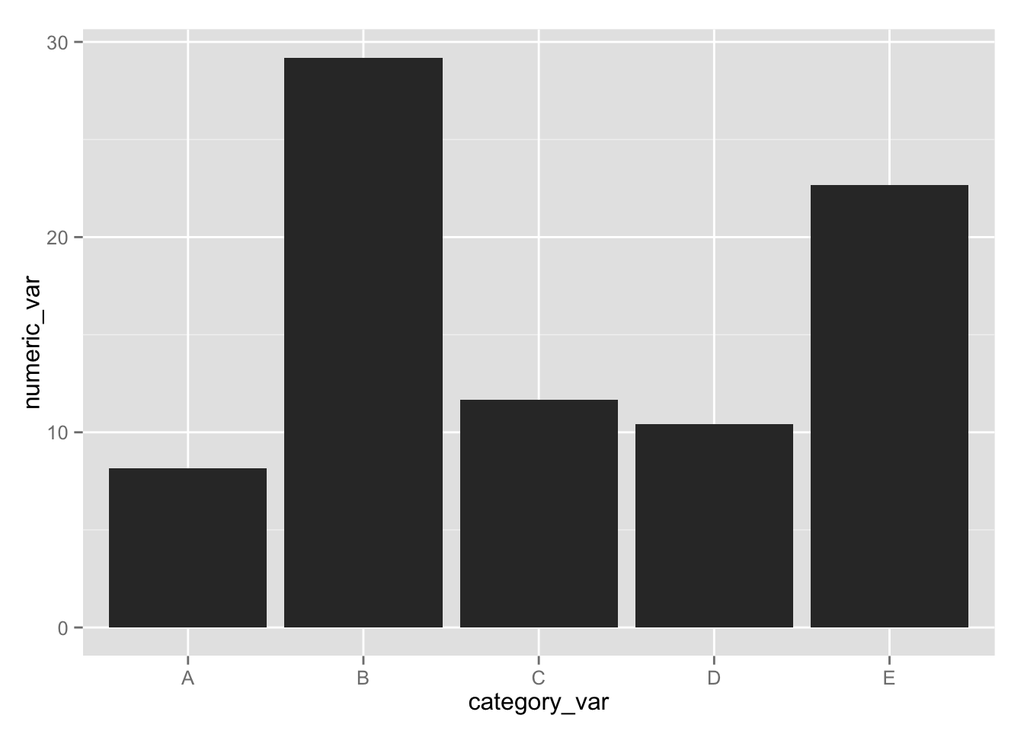

```r
# Load ggplot2 graphics package
library(ggplot2)
set.seed(8123465)
# Create dummy dataset
df.dummy_data <- data.frame(category_var = c("A","B","C","D","E"),
                          numeric_var = runif(5,2,40)
                          )

# Plot dataset with ggplot2
ggplot(data=df.dummy_data, aes(x=category_var, y=numeric_var)) +
  geom_bar(stat="identity")
```

### 指定数据集、数据关系与画图

以直方图为例，我们需要指定数据集、数据关系，然后画图，在上述代码中。

`ggplot(data=df.dummy_data, aes(x=category_var, y=numeric_var))` 指定了数据集合。aes()函数指定了数据集合与图形属性的关系。`geom_bar()`函数画图，`geom_bar(stat="identity")`，这里我们使用`stat="identity"`是因为，一般bar图有两种类型，一种是统计每个类别的数量，一种是直接画每个类别的值。这里是画每个类别对应的值所以使用`stat="identity"`。

声明: 本文采用 [BY-NC-SA](http://creativecommons.org/licenses/by-nc-sa/3.0/) 授权。转载请注明转自: tegulia

« Ggplot2图形的格式化调整示例

Ggplot自构建函数需要注意的三个问题 »